# 6 Response Surface Methodology

- Show All Code
- Hide All Code
- View Source

## 6.1 Overview

The goal of **Response Surface Methodology** (RSM) is to construct a mathematical model — a *response surface* — that approximates the relationship between a set of input factors and an output response [1,2]. In the context of BLISS-RS, the factors are the system-level design variables $Z$ and coupling variables $Y^*$, and the response is the locally-optimal BB output $F_k^*$.

RSM was originally developed for physical experiments where noise is present. When applied to *computer experiments* (deterministic simulations), there is no measurement error: running the same code twice with the same inputs always produces the same output. This changes how sample points should be placed — classical designs that replicate observations to estimate variance are wasteful; instead, the emphasis shifts to efficient space-filling.

BLISS-RS uses RSM in the computer-experiment sense: each “experiment” is a local black-box optimization, and the response surface is fitted through the resulting optimal outputs.

## 6.2 Construction of Empirical Models

### 6.2.1 Linear Regression

In most RSM applications, the true response function is unknown and we seek a polynomial approximation. The simplest choice is a **first-order (linear) model** with $n$ independent variables:

$$Y = \beta_0 + \sum_{i=1}^{n} \beta_i x_i + \varepsilon
\tag{6.1}$$

where $\beta_0, \beta_1, \ldots, \beta_n$ are unknown regression coefficients and $\varepsilon$ is a random error (zero for deterministic computer experiments).

This is a *linear model* because it is a linear function of the unknown parameters $\beta$, not necessarily of the variables $x_i$. Interaction terms ($\beta_{12} x_1 x_2$) and squared terms ($\beta_{11} x_1^2$) can be added while maintaining linearity in parameters.

Suppose the response $Y$ is observed $m$ times. Each observation $y_i$ satisfies:

$$y_i = \beta_0 + \sum_{j=1}^n \beta_j x_{ij} + \varepsilon_i, \quad i = 1, 2, \ldots, m
\tag{6.2}$$

In matrix form:

$$\{y\} = [X]\{\beta\} + \{\varepsilon\}
\tag{6.3}$$

where $\{y\}$ is $m \times 1$, $[X]$ is an $m \times p$ *design matrix*, $\{\beta\}$ is $p \times 1$, and $\{\varepsilon\}$ is $m \times 1$.

**Least squares estimation** minimises the sum of squared residuals:

$$L = \{\varepsilon\}^T\{\varepsilon\} = (\{y\} - [X]\{\beta\})^T(\{y\} - [X]\{\beta\})
\tag{6.4}$$

Setting $\partial L / \partial \{\beta\} = 0$ yields the *normal equations*:

$$[X]^T[X]\{b\} = [X]^T\{y\}
\tag{6.5}$$

The least-squares estimator $\{b\}$ of $\{\beta\}$ is:

$$\{b\} = \left([X]^T[X]\right)^{-1}[X]^T\{y\}
\tag{6.6}$$

The fitted values are:

$$\{\hat{y}\} = [X]\{b\}
\tag{6.7}$$

### 6.2.2 Second-Order Models

For BLISS-RS, first-order models are generally insufficient because the BB responses exhibit curvature. A **second-order (quadratic) model** adds pure quadratic and cross-product (interaction) terms:

$$Y = \beta_0 + \sum_{i=1}^n \beta_i x_i + \sum_{i=1}^n \beta_{ii} x_i^2
+ \sum_{i < j} \beta_{ij} x_i x_j
\tag{6.8}$$

The minimum number of observations required to uniquely fit a second-order model in $n$ variables is:

$$N_S = \frac{n^2 + 3n + 2}{2}
\tag{6.9}$$

```julia
println("| n | p (coefficients) | NS (min. points) | NS / p |")
println("|---|-----------------|-----------------|-------|")
for n in 1:12
    p  = 1 + n + n*(n+1)÷2
    ns = min_rs_points(n)
    println("| $n | $p | $ns | $(round(ns/p, digits=2)) |")
end
```

Table 6.1: Minimum sample points for a second-order RS model by number of design variables. Columns also show the total number of regression coefficients p.

```
| n | p (coefficients) | NS (min. points) | NS / p |
|---|-----------------|-----------------|-------|
| 1 | 3 | 3 | 1.0 |
| 2 | 6 | 6 | 1.0 |
| 3 | 10 | 10 | 1.0 |
| 4 | 15 | 15 | 1.0 |
| 5 | 21 | 21 | 1.0 |
| 6 | 28 | 28 | 1.0 |
| 7 | 36 | 36 | 1.0 |
| 8 | 45 | 45 | 1.0 |
| 9 | 55 | 55 | 1.0 |
| 10 | 66 | 66 | 1.0 |
| 11 | 78 | 78 | 1.0 |
| 12 | 91 | 91 | 1.0 |
```

Note that $N_S = p$ — the minimum design is exactly determined, with no degrees of freedom for error estimation. In practice, BLISS-RS uses slightly more than $N_S$ points (over-determined system) to improve conditioning and fit robustness.

### 6.2.3 Julia Implementation

Listing 6.1

```julia
# Build the [X] design matrix for a second-order model
# (duplicated here for clarity; full implementation in src/bliss_rs.jl)
function build_quadratic_X(pts::Matrix{Float64})
    m, n = size(pts)
    p = 1 + n + n*(n+1)÷2
    X = ones(m, p)
    X[:, 2:n+1] = pts
    col = n + 2
    for i in 1:n, j in i:n
        X[:, col] = pts[:, i] .* pts[:, j]
        col += 1
    end
    return X
end

# Demonstrate on a simple 2-variable quadratic function
# f(x1, x2) = 3 + 2x1 - x2 + 0.5*x1^2 + x1*x2 - 0.3*x2^2
true_β = [3.0, 2.0, -1.0, 0.5, 1.0, -0.3]
f_true(x1, x2) = true_β' * [1, x1, x2, x1^2, x1*x2, x2^2]

# Sample 12 points (> NS = 6 for n=2)
rng = MersenneTwister(42)
pts = 2 .* rand(rng, 12, 2) .- 1.0    # in [-1, 1]²
y   = [f_true(pts[i,1], pts[i,2]) for i in 1:12]

# Fit the RS
X_mat = build_quadratic_X(pts)
b_hat = (X_mat' * X_mat) \ (X_mat' * y)

@printf("True β:   [%.2f, %.2f, %.2f, %.2f, %.2f, %.2f]\n", true_β...)
@printf("Fitted b: [%.2f, %.2f, %.2f, %.2f, %.2f, %.2f]\n", b_hat...)
@printf("Max coefficient error: %.4f\n", maximum(abs.(b_hat .- true_β)))
```

```
True β:   [3.00, 2.00, -1.00, 0.50, 1.00, -0.30]
Fitted b: [3.00, 2.00, -1.00, 0.50, 1.00, -0.30]
Max coefficient error: 0.0000
```

With 12 points for a 2-variable model ($N_S = 6$), the least-squares fit recovers the true quadratic exactly (within floating-point precision), confirming the implementation.

## 6.3 Error Analysis of Fitted Response Surfaces

### 6.3.1 Test Functions

Altus (2002) assessed RS accuracy using two test functions across a range of dimensionalities $N_X$ and sample sizes $N_S$ [3]:

**Test 1** — Fitting a quadratic RS to a *quadratic* function. A correctly implemented quadratic model recovers a quadratic function exactly when $N_S \geq N_S^{\min}$, so this is a code-verification test, not a fidelity test.

**Test 2** — Fitting a quadratic RS to the generalised **Rosenbrock (Banana) function**, which has a narrow curved valley and is substantially non-quadratic:

$$f(\mathbf{x}) = \sum_{i=1}^{N_X - 1}\left[100(x_{i+1} - x_i^2)^2 + (x_i - 1)^2\right]
\tag{6.10}$$

### 6.3.2 Corrected Error Metrics

The original thesis reported a single point-wise normalized error:

$$\text{Error}_{\text{Altus}} = \frac{|f_{\text{actual}} - f_{RS}|}{|f_{\text{actual}}|}
\tag{6.11}$$

This metric has two deficiencies identified during IV&V:

1. **Singularity** — when $f_{\text{actual}} \to 0$ (e.g. the aeroelastic twist variable $\Theta$, which can change sign during optimization), the metric diverges. The original MATLAB code masked this with an implicit numerical floor.
2. **Point-wise only** — no summary statistic across the design space, no out-of-sample validation, no confidence information.

The corrected validation framework uses three complementary metrics:

$$\text{RMSE} = \sqrt{\frac{1}{m}\sum_{i=1}^{m}(y_i - \hat{y}_i)^2}
\tag{6.12}$$

$$R^2 = 1 - \frac{\sum(y_i - \hat{y}_i)^2}{\sum(y_i - \bar{y})^2}
\tag{6.13}$$

$$\text{NMAE} = \frac{1}{m}\sum_{i=1}^{m}
\frac{|y_i - \hat{y}_i|}{\max(|y_i|,\, \varepsilon \cdot \max_j|y_j|)}
\tag{6.14}$$

```julia
rosenbrock(x) = sum(100*(x[i+1] - x[i]^2)^2 + (x[i]-1)^2 for i in 1:length(x)-1)

println("| NX | NS | In-sample R² | LOOCV RMSE | LOOCV R² | LOOCV NMAE |")
println("|----|----|-------------|------------|----------|------------|")

for (nv, ns_extra) in [(2, 10), (3, 15), (5, 30), (8, 60)]
    ns = min_rs_points(nv) + ns_extra
    pts = lhs_points(nv, ns; seed=42)
    pts_coded = 2 .* pts .- 1.0   # map [0,1] → [-1,1]
    y = [rosenbrock(pts_coded[i,:]) for i in 1:ns]

    v = rs_validate(pts, y)
    @printf("| %2d | %3d | %.4f | %.2f | %.4f | %.4f |\n",
            nv, ns,
            v.insample.r2,
            v.loocv.rmse,
            v.loocv.r2,
            v.loocv.normalized_mae)
end
```

```
| NX | NS | In-sample R² | LOOCV RMSE | LOOCV R² | LOOCV NMAE |
|----|----|-------------|------------|----------|------------|
|  2 |  16 | 0.7362 | 54.89 | -0.1488 | 3.5309 |
|  3 |  25 | 0.8285 | 71.37 | 0.2023 | 0.6986 |
|  5 |  51 | 0.9060 | 81.27 | 0.6562 | 0.3874 |
|  8 | 105 | 0.8874 | 123.06 | 0.5979 | 0.3298 |
```

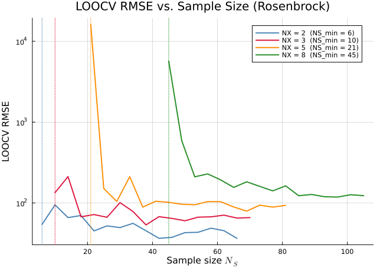

```julia
rosenbrock(x) = sum(100*(x[i+1] - x[i]^2)^2 + (x[i]-1)^2 for i in 1:length(x)-1)

function rs_loocv_study(n_vars; seed=42)
    ns_min = min_rs_points(n_vars)
    ns_range = ns_min:4:(ns_min + 60)
    rmse_vec = Float64[]
    r2_vec   = Float64[]
    for ns in ns_range
        pts = lhs_points(n_vars, ns; seed=seed)
        pts_coded = 2 .* pts .- 1.0
        y = [rosenbrock(pts_coded[i,:]) for i in 1:ns]
        loo = loocv_error(pts, y)
        push!(rmse_vec, loo.rmse)
        push!(r2_vec,   max(loo.r2, -1.0))
    end
    return collect(ns_range), rmse_vec, r2_vec
end

colors = [:steelblue, :crimson, :darkorange, :forestgreen]
p = plot(title="LOOCV RMSE vs. Sample Size (Rosenbrock)",
         xlabel=L"Sample size $N_S$",
         ylabel="LOOCV RMSE",
         yscale=:log10, legend=:topright, grid=true, gridalpha=0.3)

for (nv, col) in zip([2, 3, 5, 8], colors)
    ns_vec, rmse_vec, _ = rs_loocv_study(nv)
    ns_min = min_rs_points(nv)
    plot!(ns_vec, max.(rmse_vec, 1e-4), lw=2, color=col,
          label="NX = $nv  (NS_min = $ns_min)")
    vline!([ns_min], color=col, lw=1, linestyle=:dot, label="")
end
p
```

### 6.3.3 Response Surface Visualization

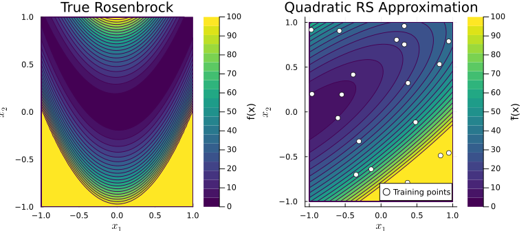

```julia
rng = MersenneTwister(77)
n_train = 20
pts = 2 .* rand(rng, n_train, 2) .- 1.0
y   = [rosenbrock(pts[i,:]) for i in 1:n_train]
b   = fit_rs(pts, y)

xg = range(-1, 1, length=60)
yg = range(-1, 1, length=60)

Z_true = [rosenbrock([xi, yi]) for yi in yg, xi in xg]
Z_rs   = [predict_rs(reshape([xi, yi], 1, 2), b)[1] for yi in yg, xi in xg]

p1 = contourf(xg, yg, min.(Z_true, 100), color=:viridis, levels=20,
              title="True Rosenbrock", xlabel=L"x_1", ylabel=L"x_2",
              colorbar_title="f(x)", clim=(0,100))

p2 = contourf(xg, yg, clamp.(Z_rs, 0, 100), color=:viridis, levels=20,
              title="Quadratic RS Approximation", xlabel=L"x_1", ylabel=L"x_2",
              colorbar_title="f̂(x)", clim=(0,100))
scatter!(pts[:,1], pts[:,2], color=:white, markersize=4,
         markerstrokecolor=:black, label="Training points")

plot(p1, p2, size=(800, 350))
```

## 6.4 Conditioning and Over-Determination

The normal equations (Equation 6.5) can become ill-conditioned when sample points are clustered or collinear. Good conditioning requires the *design matrix* $[X]$ to have columns that are mutually uncorrelated — a property promoted by the D-optimal design strategy described in Chapter 5.

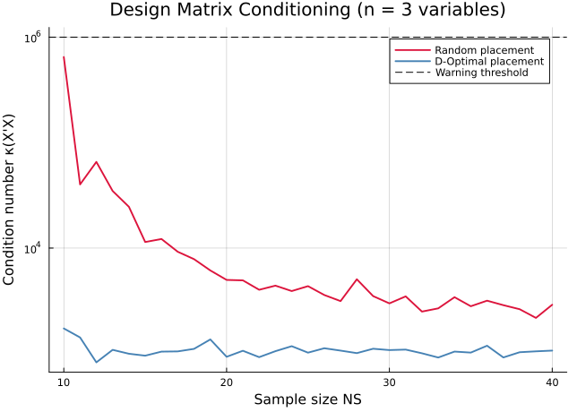

Figure 6.3: Condition number of X’X as a function of sample size and point placement strategy. Clustered random points can produce high condition numbers, increasing sensitivity to numerical errors. Well-placed D-optimal designs maintain low condition numbers.

```julia
function condition_number_study(n_vars::Int, n_pts_range, n_trials::Int=10; seed=42)
    rng = MersenneTwister(seed)
    cond_random = Float64[]
    cond_dopt   = Float64[]

    for n_pts in n_pts_range
        # Random points
        conds = Float64[]
        for trial in 1:n_trials
            pts = rand(rng, n_pts, n_vars)
            X   = rs_design_matrix(pts)
            push!(conds, cond(X' * X))
        end
        push!(cond_random, median(conds))

        # D-optimal points
        pts_d = d_optimal_points(n_vars, n_pts; seed=seed+1)
        X_d   = rs_design_matrix(pts_d)
        push!(cond_dopt, cond(X_d' * X_d))
    end
    return cond_random, cond_dopt
end

n_vars = 3
ns_min = min_rs_points(n_vars)
n_pts_range = ns_min:(ns_min + 30)

cond_r, cond_d = condition_number_study(n_vars, n_pts_range)

plot(n_pts_range, cond_r, lw=2, color=:crimson, label="Random placement",
     xlabel="Sample size NS", ylabel="Condition number κ(X'X)",
     title="Design Matrix Conditioning (n = $n_vars variables)",
     yscale=:log10, legend=:topright, grid=true, gridalpha=0.3)
plot!(n_pts_range, cond_d, lw=2, color=:steelblue, label="D-Optimal placement")
hline!([1e6], color=:black, linestyle=:dash, lw=1, label="Warning threshold")
```

[1]

Myers, R. H., and Montgomery, D. C., “Response Surface Methodology: Process and Product Optimization Using Designed Experiments,” John Wiley & Sons, New York, 2002.

[2]

Box, G. E. P., and Draper, N. R., “Empirical Model-Building and Response Surfaces,” John Wiley & Sons, New York, 1987.

[3]

Altus, T. D., “A Response Surface Methodology for Bi-Level Integrated System Synthesis (BLISS),” NASA/CR-2002-211652, NASA Langley Research Center / George Washington University, Hampton, VA, 2002.